# Modelos Estadísticos: RETO 2

IDENTIFICADOR GRUPO

## EJERCICIOS

### EJERCICIO 1

Analizad a nivel descriptivo (mediante representaciones tabulares y gráficas) y comentad brevemente todas las variables incluidas en la base de datos excepto la variable de registro (*id*}). (1 punto)

```r
library(tidyverse)


# Cargar datos de entrenamiento
train <- read_csv("train.csv")


# Comprobar estructura de los datos
glimpse(train)
```

```
Rows: 103,904
Columns: 25
$ ...1               <dbl> 0, 1, 2, 3, 4, 5, 6, 7, 8, 9, 10, 11, 12, 13, 14, 15, 16, 17, 18, 19, 20, 21, 22, 23, 24, 25, 26, 27, 28, 29, 30, 31, 32, 33, 34, 35, 36, …
$ id                 <dbl> 70172, 5047, 110028, 24026, 119299, 111157, 82113, 96462, 79485, 65725, 34991, 51412, 98628, 83502, 95789, 100580, 71142, 127461, 70354, 6…
$ Gender             <chr> "Male", "Male", "Female", "Female", "Male", "Female", "Male", "Female", "Female", "Male", "Female", "Female", "Male", "Male", "Female", "M…
$ Customer.Type      <chr> "Loyal Customer", "disloyal Customer", "Loyal Customer", "Loyal Customer", "Loyal Customer", "Loyal Customer", "Loyal Customer", "Loyal Cu…
$ Age                <dbl> 13, 25, 26, 25, 61, 26, 47, 52, 41, 20, 24, 12, 53, 33, 26, 13, 26, 41, 45, 38, 9, 17, 43, 58, 23, 57, 33, 49, 36, 22, 31, 15, 35, 67, 37,…
$ Type.Travel        <chr> "Personal Travel", "Business travel", "Business travel", "Business travel", "Business travel", "Personal Travel", "Personal Travel", "Busi…
$ Class              <chr> "Eco Plus", "Business", "Business", "Business", "Business", "Eco", "Eco", "Business", "Business", "Eco", "Eco", "Eco Plus", "Eco", "Eco", …
$ Flight.Distance    <dbl> 460, 235, 1142, 562, 214, 1180, 1276, 2035, 853, 1061, 1182, 308, 834, 946, 453, 486, 2123, 2075, 2486, 460, 1174, 208, 752, 2139, 452, 71…
$ Sat.wifi           <dbl> 3, 3, 2, 2, 3, 3, 2, 4, 1, 3, 4, 2, 1, 4, 3, 2, 3, 4, 4, 2, 2, 3, 3, 4, 5, 4, 1, 4, 3, 3, 4, 2, 4, 4, 3, 1, 3, 4, 4, 1, 4, 3, 0, 3, 1, 1, …
$ Sat.DepArr         <dbl> 4, 2, 2, 5, 3, 4, 4, 3, 2, 3, 5, 4, 4, 2, 2, 1, 3, 4, 4, 3, 4, 1, 5, 5, 0, 4, 1, 4, 1, 2, 4, 2, 5, 5, 3, 4, 4, 3, 4, 1, 4, 5, 0, 3, 1, 1, …
$ Sat.onlineBooking  <dbl> 3, 3, 2, 5, 3, 2, 2, 4, 2, 3, 5, 2, 4, 4, 3, 2, 3, 2, 4, 3, 2, 3, 3, 4, 5, 4, 1, 4, 1, 3, 4, 2, 4, 4, 3, 4, 4, 4, 4, 1, 4, 3, 0, 3, 1, 1, …
$ Sat.Gate           <dbl> 1, 3, 2, 5, 3, 1, 3, 4, 2, 4, 4, 2, 4, 3, 2, 3, 3, 4, 4, 2, 4, 3, 5, 5, 1, 1, 1, 4, 1, 3, 4, 3, 4, 1, 4, 4, 3, 2, 3, 2, 4, 4, 3, 3, 1, 1, …
$ Sat.Food           <dbl> 5, 1, 5, 2, 4, 1, 2, 5, 4, 2, 2, 1, 1, 4, 2, 4, 4, 4, 3, 5, 2, 5, 5, 4, 1, 5, 1, 2, 1, 3, 5, 5, 4, 2, 1, 1, 5, 2, 2, 1, 3, 3, 2, 2, 3, 5, …
$ Sat.OnlineBoarding <dbl> 3, 3, 5, 2, 5, 2, 2, 5, 3, 3, 5, 2, 1, 4, 3, 2, 4, 4, 4, 3, 2, 3, 4, 3, 5, 4, 5, 2, 2, 3, 5, 2, 4, 4, 3, 1, 4, 4, 4, 1, 5, 3, 5, 1, 5, 5, …
$ Sat.Seat           <dbl> 5, 1, 5, 2, 5, 1, 2, 5, 3, 3, 2, 1, 1, 4, 2, 1, 4, 4, 5, 5, 1, 5, 5, 4, 1, 5, 3, 1, 1, 1, 5, 5, 4, 5, 1, 1, 2, 2, 5, 1, 5, 3, 3, 4, 5, 5, …
$ Sat.Entertainment  <dbl> 5, 1, 5, 2, 3, 1, 2, 5, 1, 2, 2, 1, 1, 4, 2, 4, 4, 5, 5, 5, 2, 5, 3, 4, 1, 5, 4, 4, 3, 3, 5, 5, 3, 5, 1, 1, 5, 2, 4, 1, 4, 3, 4, 5, 3, 5, …
$ Sat.OnboardPers    <dbl> 4, 1, 4, 2, 3, 3, 3, 5, 1, 2, 3, 1, 1, 4, 4, 2, 5, 5, 5, 1, 1, 2, 3, 4, 4, 3, 4, 4, 3, 2, 5, 3, 3, 5, 4, 3, 5, 5, 4, 3, 4, 4, 4, 5, 3, 4, …
$ Sat.LegRoom        <dbl> 3, 5, 3, 5, 4, 4, 3, 5, 2, 3, 3, 2, 1, 5, 3, 1, 3, 5, 5, 2, 5, 5, 3, 4, 5, 2, 4, 4, 3, 4, 4, 1, 4, 4, 1, 5, 4, 1, 4, 3, 4, 4, 4, 5, 3, 2, …
$ Sat.Baggage        <dbl> 4, 3, 4, 3, 4, 4, 4, 5, 1, 4, 5, 5, 3, 2, 2, 4, 4, 5, 5, 4, 3, 3, 5, 4, 5, 4, 3, 4, 3, 3, 3, 4, 5, 3, 3, 3, 5, 4, 4, 4, 4, 5, 4, 5, 3, 5, …
$ Sat.CheckIn        <dbl> 4, 1, 4, 1, 3, 4, 3, 4, 4, 4, 3, 5, 4, 2, 2, 1, 5, 3, 3, 3, 4, 3, 3, 2, 3, 4, 5, 2, 2, 4, 1, 2, 4, 5, 1, 3, 4, 3, 4, 4, 4, 5, 4, 2, 4, 5, …
$ Sat.InflightServ   <dbl> 5, 4, 4, 4, 3, 4, 5, 5, 1, 3, 5, 5, 4, 2, 1, 3, 4, 5, 5, 2, 3, 4, 3, 4, 5, 5, 4, 4, 3, 2, 5, 4, 3, 5, 4, 3, 5, 4, 4, 4, 4, 5, 4, 5, 3, 4, …
$ Sat.Cleanliness    <dbl> 5, 1, 5, 2, 3, 1, 2, 4, 2, 2, 2, 1, 1, 4, 2, 4, 4, 5, 4, 5, 2, 5, 4, 2, 1, 5, 2, 2, 2, 3, 5, 5, 4, 5, 1, 1, 5, 2, 4, 1, 3, 3, 3, 4, 5, 5, …
$ Dep.delay          <dbl> 25, 1, 0, 11, 0, 0, 9, 4, 0, 0, 0, 0, 28, 0, 43, 1, 49, 0, 7, 17, 0, 0, 52, 0, 54, 27, 0, 0, 18, 19, 0, 3, 109, 18, 9, 0, 0, 23, 23, 0, 0,…
$ Arr.delay          <dbl> 18, 6, 0, 9, 0, 0, 23, 0, 0, 0, 0, 0, 8, 0, 35, 0, 51, 10, 5, 18, 4, 0, 29, 0, 44, 28, 0, 8, 12, 0, 0, 0, 120, 24, 0, 1, 0, 20, 31, 0, 0, …
$ Satisfaction       <chr> "neutral or dissatisfied", "neutral or dissatisfied", "satisfied", "neutral or dissatisfied", "satisfied", "neutral or dissatisfied", "neu…
```

```r
# Identificar tipos de variables automáticamente


# Variables numéricas
vars_numericas <- train |>
  select(where(is.numeric)) |>
  names()
```

[output not shown]

### EJERCICIO 2

Ejecutad y comentad brevemente análisis bivariados entre la variable de respuesta (*Satisfaction*) y el resto de variables de la base de datos excepto la variable de registro (*id*). (1.5 puntos)

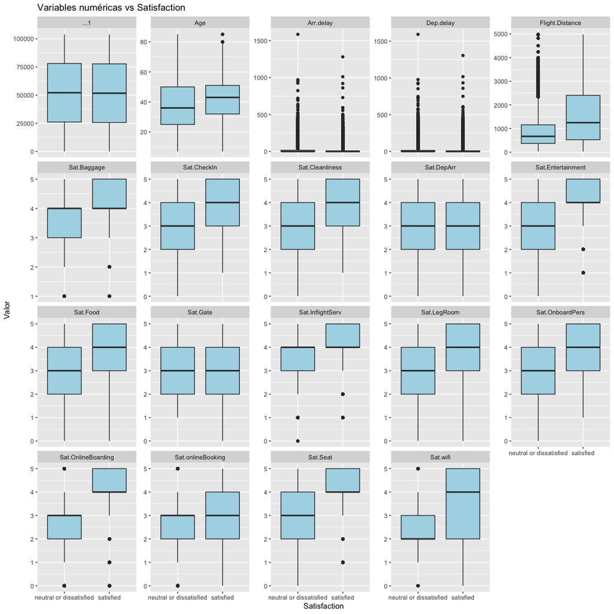

```r
 # Pregunta 2: Análisis bivariado


library(tidyverse)

# Cargar datos de entrenamiento
train <- read_csv("train.csv")


# Eliminar variable de registro si existe

if ("id" %in% names(train)) {
  train <- train |> select(-id)
}


# Definir variable respuesta

response_var <- "Satisfaction"

# -------------------------
# Identificar tipos de variables
# -------------------------

vars_numericas <- train |>
  select(where(is.numeric)) |>
  names() |>
  setdiff(response_var)

vars_categoricas <- train |>
  select(where(~ !is.numeric(.))) |>
  names() |>
  setdiff(response_var)


# Análisis bivariado

# 1. Variables numéricas vs Satisfaction


train |>
  pivot_longer(
    cols = all_of(vars_numericas),
    names_to = "variable",
    values_to = "valor"
  ) |>
  ggplot(aes(x = factor(Satisfaction), y = valor)) +
  geom_boxplot(fill = "lightblue") +
  facet_wrap(~variable, scales = "free_y") +
  labs(
    title = "Variables numéricas vs Satisfaction",
    x = "Satisfaction",
    y = "Valor"
  )
```

```r
# Contrastes no paramétricos (Wilcoxon)
resultados_wilcoxon <- lapply(
  vars_numericas,
  function(var) {
    wilcox.test(
      train[[var]] ~ train[[response_var]]
    )$p.value
  }
)

names(resultados_wilcoxon) <- vars_numericas
resultados_wilcoxon
```

```
$...1
[1] 0.1273

$Age
[1] 0

$Flight.Distance
[1] 0

$Sat.wifi
[1] 0

$Sat.DepArr
[1] 1.754436e-57

$Sat.onlineBooking
[1] 0

$Sat.Gate
[1] 0.9646642

$Sat.Food
[1] 0

$Sat.OnlineBoarding
[1] 0

$Sat.Seat
[1] 0

$Sat.Entertainment
[1] 0

$Sat.OnboardPers
[1] 0

$Sat.LegRoom
[1] 0

$Sat.Baggage
[1] 0

$Sat.CheckIn
[1] 0

$Sat.InflightServ
[1] 0

$Sat.Cleanliness
[1] 0

$Dep.delay
[1] 3.153596e-106

$Arr.delay
[1] 1.267778e-229
```

```r
# 2. Variables categóricas vs Satisfaction

tablas_chi2 <- lapply(
  vars_categoricas,
  function(var) {
    table(train[[var]], train[[response_var]])
  }
)

names(tablas_chi2) <- vars_categoricas
tablas_chi2
```

```
$Gender

         neutral or dissatisfied satisfied
  Female                   30193     22534
  Male                     28686     22491

$Customer.Type

                    neutral or dissatisfied satisfied
  disloyal Customer                   14489      4492
  Loyal Customer                      44390     40533

$Type.Travel

                  neutral or dissatisfied satisfied
  Business travel                   29909     41746
  Personal Travel                   28970      3279

$Class

           neutral or dissatisfied satisfied
  Business                   15185     34480
  Eco                        38044      8701
  Eco Plus                    5650      1844
```

```r
# Test Chi-cuadrado
resultados_chi2 <- lapply(
  vars_categoricas,
  function(var) {
    chisq.test(
      table(train[[var]], train[[response_var]])
    )$p.value
  }
)

names(resultados_chi2) <- vars_categoricas
resultados_chi2
```

```
$Gender
[1] 8.496755e-05

$Customer.Type
[1] 0

$Type.Travel
[1] 0

$Class
[1] 0
```

### EJERCICIO 3

Llevad a cabo el ajuste de un modelo de regresión logística para clasificar a los individuos de acuerdo a la variable *Satisfaction*, utilizando la muestra de entrenamiento. Podéis utilizar términos no lineales como polinomios e interacciones para mejorar el ajuste. Justificad y explicad el modelo final al que se llega con este procedimiento. (2 puntos)

```r
#Regresión logística

library(tidyverse)
library(effects)
library(car)
library(pscl)

# Cargar datos de entrenamiento
train <- read_csv("train.csv")

# Eliminar variable de registro si existe
if ("id" %in% names(train)) {
  train <- train |> dplyr::select(-id)
}

# Preparar variable respuesta
train <- train |>
  mutate(Satisfaction = factor(Satisfaction))


# Eliminar observaciones con NA

train <- train |> drop_na()


# -------------------------
# Identificar variables
# -------------------------

vars_numericas <- train |>
  dplyr::select(where(is.numeric)) |>
  names()

vars_categoricas <- train |>
  dplyr::select(where(~ !is.numeric(.))) |>
  names() |>
  setdiff("Satisfaction")

# Convertir categóricas a factor
train <- train |>
  mutate(across(all_of(vars_categoricas), factor))

# -------------------------
# Modelo logístico base
# -------------------------

modelo_logit_base <- glm(
  Satisfaction ~ .,
  data = train,
  family = binomial
)

summary(modelo_logit_base)
```

```
Call:
glm(formula = Satisfaction ~ ., family = binomial, data = train)

Coefficients:
                              Estimate Std. Error z value Pr(>|z|)
(Intercept)                 -7.821e+00  8.037e-02 -97.320  < 2e-16 ***
...1                        -7.623e-07  3.239e-07  -2.353  0.01861 *
GenderMale                   4.289e-02  1.950e-02   2.200  0.02782 *
Customer.TypeLoyal Customer  2.035e+00  2.995e-02  67.967  < 2e-16 ***
Age                         -8.310e-03  7.111e-04 -11.686  < 2e-16 ***
Type.TravelPersonal Travel  -2.722e+00  3.147e-02 -86.493  < 2e-16 ***
ClassEco                    -7.390e-01  2.566e-02 -28.795  < 2e-16 ***
ClassEco Plus               -8.553e-01  4.155e-02 -20.584  < 2e-16 ***
Flight.Distance             -1.784e-05  1.132e-05  -1.576  0.11500
Sat.wifi                     3.947e-01  1.148e-02  34.388  < 2e-16 ***
Sat.DepArr                  -1.243e-01  8.219e-03 -15.128  < 2e-16 ***
Sat.onlineBooking           -1.439e-01  1.135e-02 -12.681  < 2e-16 ***
Sat.Gate                     2.923e-02  9.174e-03   3.187  0.00144 **
Sat.Food                    -2.858e-02  1.068e-02  -2.675  0.00748 **
Sat.OnlineBoarding           6.127e-01  1.025e-02  59.782  < 2e-16 ***
Sat.Seat                     6.568e-02  1.118e-02   5.873 4.27e-09 ***
Sat.Entertainment            6.559e-02  1.427e-02   4.597 4.30e-06 ***
Sat.OnboardPers              3.016e-01  1.019e-02  29.590  < 2e-16 ***
Sat.LegRoom                  2.533e-01  8.540e-03  29.664  < 2e-16 ***
Sat.Baggage                  1.330e-01  1.144e-02  11.626  < 2e-16 ***
Sat.CheckIn                  3.235e-01  8.567e-03  37.757  < 2e-16 ***
Sat.InflightServ             1.207e-01  1.205e-02  10.011  < 2e-16 ***
Sat.Cleanliness              2.235e-01  1.210e-02  18.463  < 2e-16 ***
Dep.delay                    4.756e-03  9.883e-04   4.812 1.49e-06 ***
Arr.delay                   -9.411e-03  9.746e-04  -9.657  < 2e-16 ***
---
Signif. codes:  0 ‘***’ 0.001 ‘**’ 0.01 ‘*’ 0.05 ‘.’ 0.1 ‘ ’ 1

(Dispersion parameter for binomial family taken to be 1)

    Null deviance: 141768  on 103593  degrees of freedom
Residual deviance:  69164  on 103569  degrees of freedom
AIC: 69214

Number of Fisher Scoring iterations: 6
```

```r
AIC(modelo_logit_base)
```

```
[1] 69213.67
```

[figure not shown]

```r
#Gráficos de efectos
plot(allEffects(modelo_logit_base))
```

```r
#Contrastes globales
Anova(modelo_logit_base, test = "Wald")
```

```
Analysis of Deviance Table (Type II tests)

Response: Satisfaction
                   Df     Chisq Pr(>Chisq)
...1                1    5.5376   0.018612 *
Gender              1    4.8393   0.027819 *
Customer.Type       1 4619.5664  < 2.2e-16 ***
Age                 1  136.5567  < 2.2e-16 ***
Type.Travel         1 7480.9993  < 2.2e-16 ***
Class               2  944.1964  < 2.2e-16 ***
Flight.Distance     1    2.4841   0.115003
Sat.wifi            1 1182.5505  < 2.2e-16 ***
Sat.DepArr          1  228.8539  < 2.2e-16 ***
Sat.onlineBooking   1  160.8006  < 2.2e-16 ***
Sat.Gate            1   10.1540   0.001440 **
Sat.Food            1    7.1531   0.007484 **
Sat.OnlineBoarding  1 3573.9441  < 2.2e-16 ***
Sat.Seat            1   34.4956  4.272e-09 ***
Sat.Entertainment   1   21.1283  4.295e-06 ***
Sat.OnboardPers     1  875.5897  < 2.2e-16 ***
Sat.LegRoom         1  879.9739  < 2.2e-16 ***
Sat.Baggage         1  135.1689  < 2.2e-16 ***
Sat.CheckIn         1 1425.6125  < 2.2e-16 ***
Sat.InflightServ    1  100.2273  < 2.2e-16 ***
Sat.Cleanliness     1  340.8934  < 2.2e-16 ***
Dep.delay           1   23.1591  1.491e-06 ***
Arr.delay           1   93.2480  < 2.2e-16 ***
---
Signif. codes:  0 ‘***’ 0.001 ‘**’ 0.01 ‘*’ 0.05 ‘.’ 0.1 ‘ ’ 1
```

```r
anova(modelo_logit_base, test = "Chisq")
```

```
Analysis of Deviance Table

Model: binomial, link: logit

Response: Satisfaction

Terms added sequentially (first to last)

                   Df Deviance Resid. Df Resid. Dev  Pr(>Chi)
NULL                              103593     141768
...1                1      2.1    103592     141766    0.1429
Gender              1     15.9    103591     141750  6.81e-05 ***
Customer.Type       1   3837.2    103590     137913 < 2.2e-16 ***
Age                 1    811.1    103589     137102 < 2.2e-16 ***
Type.Travel         1  31473.7    103588     105628 < 2.2e-16 ***
Class               2   5492.8    103586     100135 < 2.2e-16 ***
Flight.Distance     1      0.0    103585     100135    0.8792
Sat.wifi            1   8951.3    103584      91184 < 2.2e-16 ***
Sat.DepArr          1   1263.4    103583      89920 < 2.2e-16 ***
Sat.onlineBooking   1    652.0    103582      89268 < 2.2e-16 ***
Sat.Gate            1    385.6    103581      88883 < 2.2e-16 ***
Sat.Food            1   1712.2    103580      87171 < 2.2e-16 ***
Sat.OnlineBoarding  1   6715.6    103579      80455 < 2.2e-16 ***
Sat.Seat            1    755.0    103578      79700 < 2.2e-16 ***
Sat.Entertainment   1   3599.5    103577      76101 < 2.2e-16 ***
Sat.OnboardPers     1   2707.5    103576      73393 < 2.2e-16 ***
Sat.LegRoom         1   1306.6    103575      72087 < 2.2e-16 ***
Sat.Baggage         1    387.4    103574      71699 < 2.2e-16 ***
Sat.CheckIn         1   1729.9    103573      69969 < 2.2e-16 ***
Sat.InflightServ    1     91.9    103572      69877 < 2.2e-16 ***
Sat.Cleanliness     1    311.6    103571      69566 < 2.2e-16 ***
Dep.delay           1    307.2    103570      69258 < 2.2e-16 ***
Arr.delay           1     94.8    103569      69164 < 2.2e-16 ***
---
Signif. codes:  0 ‘***’ 0.001 ‘**’ 0.01 ‘*’ 0.05 ‘.’ 0.1 ‘ ’ 1
```

```r
# -------------------------
# Modelo con no linealidad (polinomios grado 2)
# -------------------------

formula_poly <- as.formula(
  paste(
    "Satisfaction ~",
    paste(
      c(
        paste0("poly(", vars_numericas, ", 2)"),
        vars_categoricas
      ),
      collapse = " + "
    )
  )
)

modelo_logit_poly <- glm(
  formula_poly,
  data = train,
  family = binomial
)

summary(modelo_logit_poly)
```

```
Call:
glm(formula = formula_poly, family = binomial, data = train)

Coefficients:
                               Estimate Std. Error z value Pr(>|z|)
(Intercept)                    -1.40721    0.03834 -36.702  < 2e-16 ***
poly(...1, 2)1                 -6.39988    4.12062  -1.553 0.120391
poly(...1, 2)2                  2.21672    4.12261   0.538 0.590786
poly(Age, 2)1                 -10.08677    4.69366  -2.149 0.031633 *
poly(Age, 2)2                 -40.21377    4.46104  -9.014  < 2e-16 ***
poly(Flight.Distance, 2)1       6.39951    4.69819   1.362 0.173159
poly(Flight.Distance, 2)2       0.14458    4.07320   0.035 0.971685
poly(Sat.wifi, 2)1            304.09060    6.93724  43.835  < 2e-16 ***
poly(Sat.wifi, 2)2            615.99060    7.81381  78.834  < 2e-16 ***
poly(Sat.DepArr, 2)1         -116.62974    5.99314 -19.461  < 2e-16 ***
poly(Sat.DepArr, 2)2          -94.68113    5.54222 -17.084  < 2e-16 ***
poly(Sat.onlineBooking, 2)1    84.68727    6.90135  12.271  < 2e-16 ***
poly(Sat.onlineBooking, 2)2    30.42932    6.99478   4.350 1.36e-05 ***
poly(Sat.Gate, 2)1            -58.46326    5.76496 -10.141  < 2e-16 ***
poly(Sat.Gate, 2)2            -85.49912    5.39704 -15.842  < 2e-16 ***
poly(Sat.Food, 2)1             -6.88960    5.81985  -1.184 0.236488
poly(Sat.Food, 2)2            -24.73895    5.58992  -4.426 9.62e-06 ***
poly(Sat.OnlineBoarding, 2)1  291.69466    5.98146  48.766  < 2e-16 ***
poly(Sat.OnlineBoarding, 2)2  199.38592    5.81267  34.302  < 2e-16 ***
poly(Sat.Seat, 2)1             22.55450    6.33277   3.562 0.000369 ***
poly(Sat.Seat, 2)2            160.29897    5.50707  29.108  < 2e-16 ***
poly(Sat.Entertainment, 2)1    33.70371    8.01313   4.206 2.60e-05 ***
poly(Sat.Entertainment, 2)2  -173.37061    7.41696 -23.375  < 2e-16 ***
poly(Sat.OnboardPers, 2)1     129.41826    5.67993  22.785  < 2e-16 ***
poly(Sat.OnboardPers, 2)2       0.08333    4.99776   0.017 0.986698
poly(Sat.LegRoom, 2)1         114.71600    4.78251  23.987  < 2e-16 ***
poly(Sat.LegRoom, 2)2          20.47471    4.53370   4.516 6.30e-06 ***
poly(Sat.Baggage, 2)1          80.37933    5.79615  13.868  < 2e-16 ***
poly(Sat.Baggage, 2)2          98.66786    5.02839  19.622  < 2e-16 ***
poly(Sat.CheckIn, 2)1         127.95050    4.62104  27.689  < 2e-16 ***
poly(Sat.CheckIn, 2)2           9.64702    4.21371   2.289 0.022054 *
poly(Sat.InflightServ, 2)1     72.09503    6.06897  11.879  < 2e-16 ***
poly(Sat.InflightServ, 2)2    111.13007    5.26329  21.114  < 2e-16 ***
poly(Sat.Cleanliness, 2)1      88.68130    6.62190  13.392  < 2e-16 ***
poly(Sat.Cleanliness, 2)2       7.43692    5.81183   1.280 0.200680
poly(Dep.delay, 2)1           -36.51062   20.76679  -1.758 0.078726 .
poly(Dep.delay, 2)2          -163.17794   25.79650  -6.326 2.52e-10 ***
poly(Arr.delay, 2)1           -27.46241   20.32019  -1.351 0.176541
poly(Arr.delay, 2)2           187.18440   25.55937   7.324 2.42e-13 ***
GenderMale                      0.04513    0.02577   1.751 0.079931 .
Customer.TypeLoyal Customer     3.00915    0.04326  69.559  < 2e-16 ***
Type.TravelPersonal Travel     -3.72748    0.04731 -78.781  < 2e-16 ***
ClassEco                       -0.69558    0.03505 -19.845  < 2e-16 ***
ClassEco Plus                  -0.93350    0.05763 -16.199  < 2e-16 ***
---
Signif. codes:  0 ‘***’ 0.001 ‘**’ 0.01 ‘*’ 0.05 ‘.’ 0.1 ‘ ’ 1

(Dispersion parameter for binomial family taken to be 1)

    Null deviance: 141768  on 103593  degrees of freedom
Residual deviance:  41180  on 103550  degrees of freedom
AIC: 41268

Number of Fisher Scoring iterations: 7
```

```r
AIC(modelo_logit_base, modelo_logit_poly)
```

|  | df | AIC |
| --- | --- | --- |
| modelo_logit_base | 25 | 69213.67 |
| modelo_logit_poly | 44 | 41268.24 |

[figure not shown]

```r
plot(allEffects(modelo_logit_poly))
```

```r
# -------------------------
#Modelo con interacciones
# -------------------------

modelo_logit_inter <- glm(
  Satisfaction ~ Customer.Type * Class + Age + Flight.Distance,
  data = train,
  family = binomial
)

summary(modelo_logit_inter)
```

```
Call:
glm(formula = Satisfaction ~ Customer.Type * Class + Age + Flight.Distance,
    family = binomial, data = train)

Coefficients:
                                            Estimate Std. Error z value Pr(>|z|)
(Intercept)                               -6.818e-01  3.027e-02 -22.522  < 2e-16 ***
Customer.TypeLoyal Customer                1.374e+00  2.824e-02  48.642  < 2e-16 ***
ClassEco                                  -1.357e+00  3.660e-02 -37.068  < 2e-16 ***
ClassEco Plus                             -2.030e+00  1.412e-01 -14.378  < 2e-16 ***
Age                                        6.240e-03  5.202e-04  11.996  < 2e-16 ***
Flight.Distance                            6.602e-05  8.616e-06   7.662 1.82e-14 ***
Customer.TypeLoyal Customer:ClassEco      -1.024e+00  4.122e-02 -24.833  < 2e-16 ***
Customer.TypeLoyal Customer:ClassEco Plus  1.215e-02  1.445e-01   0.084    0.933
---
Signif. codes:  0 ‘***’ 0.001 ‘**’ 0.01 ‘*’ 0.05 ‘.’ 0.1 ‘ ’ 1

(Dispersion parameter for binomial family taken to be 1)

    Null deviance: 141768  on 103593  degrees of freedom
Residual deviance: 110201  on 103586  degrees of freedom
AIC: 110217

Number of Fisher Scoring iterations: 4
```

```r
AIC(modelo_logit_base, modelo_logit_inter)
```

|  | df | AIC |
| --- | --- | --- |
| modelo_logit_base | 25 | 69213.67 |
| modelo_logit_inter | 8 | 110217.35 |

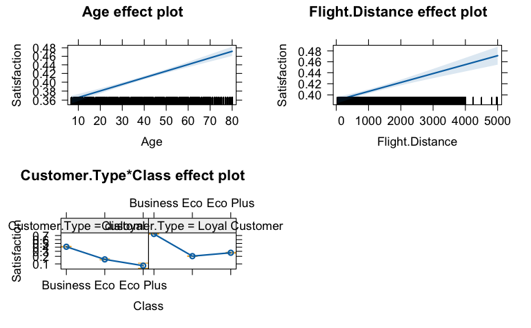

```r
plot(allEffects(modelo_logit_inter))
```

```r
# -------------------------
#Selección de modelo (stepwise, reducción de dimensionalidad en ambas direcciones)
# -------------------------
modelo_step <- step(modelo_logit_base, direction = "both")
```

```
Start:  AIC=69213.67
Satisfaction ~ ...1 + Gender + Customer.Type + Age + Type.Travel +
    Class + Flight.Distance + Sat.wifi + Sat.DepArr + Sat.onlineBooking +
    Sat.Gate + Sat.Food + Sat.OnlineBoarding + Sat.Seat + Sat.Entertainment +
    Sat.OnboardPers + Sat.LegRoom + Sat.Baggage + Sat.CheckIn +
    Sat.InflightServ + Sat.Cleanliness + Dep.delay + Arr.delay

                     Df Deviance   AIC
<none>                     69164 69214
- Flight.Distance     1    69166 69214
- Gender              1    69169 69217
- ...1                1    69169 69217
- Sat.Food            1    69171 69219
- Sat.Gate            1    69174 69222
- Sat.Entertainment   1    69185 69233
- Dep.delay           1    69187 69235
- Sat.Seat            1    69198 69246
- Arr.delay           1    69258 69306
- Sat.InflightServ    1    69264 69312
- Sat.Baggage         1    69300 69348
- Age                 1    69301 69349
- Sat.onlineBooking   1    69325 69373
- Sat.DepArr          1    69392 69440
- Sat.Cleanliness     1    69506 69554
- Sat.LegRoom         1    70050 70098
- Sat.OnboardPers     1    70056 70104
- Class               2    70107 70153
- Sat.wifi            1    70386 70434
- Sat.CheckIn         1    70637 70685
- Sat.OnlineBoarding  1    72965 73013
- Customer.Type       1    74242 74290
- Type.Travel         1    77958 78006
```

```r
summary(modelo_step)
```

```
Call:
glm(formula = Satisfaction ~ ...1 + Gender + Customer.Type +
    Age + Type.Travel + Class + Flight.Distance + Sat.wifi +
    Sat.DepArr + Sat.onlineBooking + Sat.Gate + Sat.Food + Sat.OnlineBoarding +
    Sat.Seat + Sat.Entertainment + Sat.OnboardPers + Sat.LegRoom +
    Sat.Baggage + Sat.CheckIn + Sat.InflightServ + Sat.Cleanliness +
    Dep.delay + Arr.delay, family = binomial, data = train)

Coefficients:
                              Estimate Std. Error z value Pr(>|z|)
(Intercept)                 -7.821e+00  8.037e-02 -97.320  < 2e-16 ***
...1                        -7.623e-07  3.239e-07  -2.353  0.01861 *
GenderMale                   4.289e-02  1.950e-02   2.200  0.02782 *
Customer.TypeLoyal Customer  2.035e+00  2.995e-02  67.967  < 2e-16 ***
Age                         -8.310e-03  7.111e-04 -11.686  < 2e-16 ***
Type.TravelPersonal Travel  -2.722e+00  3.147e-02 -86.493  < 2e-16 ***
ClassEco                    -7.390e-01  2.566e-02 -28.795  < 2e-16 ***
ClassEco Plus               -8.553e-01  4.155e-02 -20.584  < 2e-16 ***
Flight.Distance             -1.784e-05  1.132e-05  -1.576  0.11500
Sat.wifi                     3.947e-01  1.148e-02  34.388  < 2e-16 ***
Sat.DepArr                  -1.243e-01  8.219e-03 -15.128  < 2e-16 ***
Sat.onlineBooking           -1.439e-01  1.135e-02 -12.681  < 2e-16 ***
Sat.Gate                     2.923e-02  9.174e-03   3.187  0.00144 **
Sat.Food                    -2.858e-02  1.068e-02  -2.675  0.00748 **
Sat.OnlineBoarding           6.127e-01  1.025e-02  59.782  < 2e-16 ***
Sat.Seat                     6.568e-02  1.118e-02   5.873 4.27e-09 ***
Sat.Entertainment            6.559e-02  1.427e-02   4.597 4.30e-06 ***
Sat.OnboardPers              3.016e-01  1.019e-02  29.590  < 2e-16 ***
Sat.LegRoom                  2.533e-01  8.540e-03  29.664  < 2e-16 ***
Sat.Baggage                  1.330e-01  1.144e-02  11.626  < 2e-16 ***
Sat.CheckIn                  3.235e-01  8.567e-03  37.757  < 2e-16 ***
Sat.InflightServ             1.207e-01  1.205e-02  10.011  < 2e-16 ***
Sat.Cleanliness              2.235e-01  1.210e-02  18.463  < 2e-16 ***
Dep.delay                    4.756e-03  9.883e-04   4.812 1.49e-06 ***
Arr.delay                   -9.411e-03  9.746e-04  -9.657  < 2e-16 ***
---
Signif. codes:  0 ‘***’ 0.001 ‘**’ 0.01 ‘*’ 0.05 ‘.’ 0.1 ‘ ’ 1

(Dispersion parameter for binomial family taken to be 1)

    Null deviance: 141768  on 103593  degrees of freedom
Residual deviance:  69164  on 103569  degrees of freedom
AIC: 69214

Number of Fisher Scoring iterations: 6
```

```r
AIC(modelo_step)
```

```
[1] 69213.67
```

```r
# Comparación de modelos

anova(modelo_logit_base, modelo_logit_poly, modelo_logit_inter, modelo_step, test = "Chisq")
```

```
Analysis of Deviance Table

Model 1: Satisfaction ~ ...1 + Gender + Customer.Type + Age + Type.Travel +
    Class + Flight.Distance + Sat.wifi + Sat.DepArr + Sat.onlineBooking +
    Sat.Gate + Sat.Food + Sat.OnlineBoarding + Sat.Seat + Sat.Entertainment +
    Sat.OnboardPers + Sat.LegRoom + Sat.Baggage + Sat.CheckIn +
    Sat.InflightServ + Sat.Cleanliness + Dep.delay + Arr.delay
Model 2: Satisfaction ~ poly(...1, 2) + poly(Age, 2) + poly(Flight.Distance,
    2) + poly(Sat.wifi, 2) + poly(Sat.DepArr, 2) + poly(Sat.onlineBooking,
    2) + poly(Sat.Gate, 2) + poly(Sat.Food, 2) + poly(Sat.OnlineBoarding,
    2) + poly(Sat.Seat, 2) + poly(Sat.Entertainment, 2) + poly(Sat.OnboardPers,
    2) + poly(Sat.LegRoom, 2) + poly(Sat.Baggage, 2) + poly(Sat.CheckIn,
    2) + poly(Sat.InflightServ, 2) + poly(Sat.Cleanliness, 2) +
    poly(Dep.delay, 2) + poly(Arr.delay, 2) + Gender + Customer.Type +
    Type.Travel + Class
Model 3: Satisfaction ~ Customer.Type * Class + Age + Flight.Distance
Model 4: Satisfaction ~ ...1 + Gender + Customer.Type + Age + Type.Travel +
    Class + Flight.Distance + Sat.wifi + Sat.DepArr + Sat.onlineBooking +
    Sat.Gate + Sat.Food + Sat.OnlineBoarding + Sat.Seat + Sat.Entertainment +
    Sat.OnboardPers + Sat.LegRoom + Sat.Baggage + Sat.CheckIn +
    Sat.InflightServ + Sat.Cleanliness + Dep.delay + Arr.delay
  Resid. Df Resid. Dev  Df Deviance  Pr(>Chi)
1    103569      69164
2    103550      41180  19    27983 < 2.2e-16 ***
3    103586     110201 -36   -69021 < 2.2e-16 ***
4    103569      69164  17    41038 < 2.2e-16 ***
---
Signif. codes:  0 ‘***’ 0.001 ‘**’ 0.01 ‘*’ 0.05 ‘.’ 0.1 ‘ ’ 1
```

```r
# -------------------------
#Diagnósticos finales
# -------------------------

#Multicolinealidad
vif(modelo_step)
```

```
                        GVIF Df GVIF^(1/(2*Df))
...1                1.000407  1        1.000204
Gender              1.007259  1        1.003623
Customer.Type       1.610464  1        1.269040
Age                 1.181439  1        1.086940
Type.Travel         1.867024  1        1.366391
Class               1.671641  2        1.137066
Flight.Distance     1.357258  1        1.165014
Sat.wifi            2.216400  1        1.488758
Sat.DepArr          1.723211  1        1.312711
Sat.onlineBooking   2.591724  1        1.609883
Sat.Gate            1.520563  1        1.233111
Sat.Food            2.008286  1        1.417140
Sat.OnlineBoarding  1.478511  1        1.215940
Sat.Seat            2.032292  1        1.425585
Sat.Entertainment   3.249901  1        1.802748
Sat.OnboardPers     1.639647  1        1.280487
Sat.LegRoom         1.215593  1        1.102539
Sat.Baggage         1.827923  1        1.352007
Sat.CheckIn         1.208377  1        1.099262
Sat.InflightServ    2.012392  1        1.418588
Sat.Cleanliness     2.457764  1        1.567726
Dep.delay          14.325494  1        3.784903
Arr.delay          14.360751  1        3.789558
```

```r
#Pseudo R2
pR2(modelo_step)
```

```
fitting null model for pseudo-r2
          llh       llhNull            G2      McFadden          r2ML          r2CU
-3.458184e+04 -7.088399e+04  7.260430e+04  5.121347e-01  5.038387e-01  6.758304e-01
```

### EJERCICIO 4

Llevad a cabo el ajuste de un modelo de clasificación basado en análisis discriminante para clasificar a los individuos de acuerdo a la variable *Satisfaction*, utilizando la muestra de entrenamiento. Justificad y explicad el modelo final al que se llega con este procedimiento. (2 puntos)

```r
library(MASS)
library(kableExtra)
library(tidyverse)
library(pROC)


# Preparar datos: seleccionar solo variables útiles
train_lda <- train |>
  dplyr::select(-any_of("id"), -starts_with("...")) |>
  dplyr::select_if(function(x) is.numeric(x) | is.factor(x))


# 2. AJUSTAR MODELO LDA
cat("### 1. ANÁLISIS DISCRIMINANTE LINEAL (LDA)\n\n")
```

```
### 1. ANÁLISIS DISCRIMINANTE LINEAL (LDA)
```

```r
modelo_lda <- lda(Satisfaction ~ ., data = train_lda)

# Resumen del modelo
print(modelo_lda)
```

```
Call:
lda(Satisfaction ~ ., data = train_lda)

Prior probabilities of groups:
neutral or dissatisfied               satisfied
              0.5666062               0.4333938

Group means:
                        GenderMale Customer.TypeLoyal Customer      Age Type.TravelPersonal Travel  ClassEco ClassEco Plus Flight.Distance Sat.wifi Sat.DepArr
neutral or dissatisfied  0.4870777                   0.7538545 37.56913                 0.49177982 0.6460637    0.09595039        928.6071 2.399748   3.129070
satisfied                0.4995434                   0.9001270 41.74856                 0.07267746 0.1931309    0.04089360       1530.1803 3.161191   2.969887
                        Sat.onlineBooking Sat.Gate Sat.Food Sat.OnlineBoarding Sat.Seat Sat.Entertainment Sat.OnboardPers Sat.LegRoom Sat.Baggage Sat.CheckIn
neutral or dissatisfied          2.547149 2.976524 2.958362           2.656337 3.037072          2.894100        3.019303    2.991107    3.375709    3.043239
satisfied                        3.031316 2.977682 3.520814           4.027285 3.966234          3.965276        3.857585    3.822438    3.966345    3.645656
                        Sat.InflightServ Sat.Cleanliness Dep.delay Arr.delay
neutral or dissatisfied         3.389015        2.936317  16.43191  17.12754
satisfied                       3.969887        3.744081  12.54636  12.63080

Coefficients of linear discriminants:
                                      LD1
GenderMale                   2.956402e-02
Customer.TypeLoyal Customer  1.250801e+00
Age                         -3.853501e-03
Type.TravelPersonal Travel  -1.544887e+00
ClassEco                    -5.203702e-01
ClassEco Plus               -5.811499e-01
Flight.Distance              4.192127e-06
Sat.wifi                     2.731016e-01
Sat.DepArr                  -6.531743e-02
Sat.onlineBooking           -1.642655e-01
Sat.Gate                     1.630663e-02
Sat.Food                    -1.898353e-02
Sat.OnlineBoarding           3.227462e-01
Sat.Seat                     3.197799e-02
Sat.Entertainment            6.663268e-02
Sat.OnboardPers              1.408669e-01
Sat.LegRoom                  1.339893e-01
Sat.Baggage                  6.674429e-02
Sat.CheckIn                  1.495869e-01
Sat.InflightServ             5.795705e-02
Sat.Cleanliness              1.017757e-01
Dep.delay                    2.151019e-03
Arr.delay                   -4.156799e-03
```

```r
# Probabilidades previas
cat("\n**Probabilidades previas (Prior):**\n")
```

```
**Probabilidades previas (Prior):**
```

```r
print(modelo_lda$prior)
```

```
neutral or dissatisfied               satisfied
              0.5666062               0.4333938
```

```r
# 3. PREDICCIONES Y EXACTITUD
cat("\n### 2. PREDICCIONES Y EXACTITUD\n\n")
```

```
### 2. PREDICCIONES Y EXACTITUD
```

```r
pred_lda <- predict(modelo_lda, newdata = train_lda)
clasificacion_lda <- pred_lda$class

# Matriz de confusión
matriz_conf_lda <- table(Predicción = clasificacion_lda,
                         Real = train_lda$Satisfaction)

cat("#### Matriz de confusión (LDA):\n")
```

```
#### Matriz de confusión (LDA):
```

```r
print(kable(matriz_conf_lda,
           caption = "Matriz de confusión - LDA",
           align = c("l", "c", "c")) |>
  kable_styling(bootstrap_options = c("striped", "hover"),
                full_width = FALSE,
                font_size = 10) |>
  column_spec(1, bold = TRUE, width = "3cm"))
```

Matriz de confusión - LDA

|  | neutral or dissatisfied | satisfied |
| --- | --- | --- |
| neutral or dissatisfied | 52845 | 7400 |
| satisfied | 5852 | 37497 |

```r
# Exactitud
exactitud_lda <- mean(clasificacion_lda == train_lda$Satisfaction)
cat("\n**Exactitud LDA en train:**", round(exactitud_lda, 4), "\n\n")
```

```
**Exactitud LDA en train:** 0.8721
```

```r
# 4. ANÁLISIS DE VARIABLES DISCRIMINANTES
cat("\n### 3. ANÁLISIS DE VARIABLES DISCRIMINANTES\n\n")
```

```
### 3. ANÁLISIS DE VARIABLES DISCRIMINANTES
```

```r
# Diferencias de medias entre grupos
means_data <- modelo_lda$means
diferencias <- means_data["satisfied", ] - means_data["neutral or dissatisfied", ]

# Top 10 variables más discriminativas
top_10 <- sort(abs(diferencias), decreasing = TRUE)[1:10]

cat("#### Top 10 variables con mayor discriminación:\n\n")
```

```
#### Top 10 variables con mayor discriminación:
```

```r
print(kable(data.frame(
  Variable = names(top_10),
  Diferencia = round(top_10, 4)
), caption = "Top 10 variables con mayor diferencia de medias entre grupos",
   align = c("l", "c")) |>
  kable_styling(bootstrap_options = c("striped", "hover"),
                full_width = FALSE))
```

Top 10 variables con mayor diferencia de medias entre grupos

|  | Variable | Diferencia |
| --- | --- | --- |
| Flight.Distance | Flight.Distance | 601.5732 |
| Arr.delay | Arr.delay | 4.4967 |
| Age | Age | 4.1794 |
| Dep.delay | Dep.delay | 3.8856 |
| Sat.OnlineBoarding | Sat.OnlineBoarding | 1.3709 |
| Sat.Entertainment | Sat.Entertainment | 1.0712 |
| Sat.Seat | Sat.Seat | 0.9292 |
| Sat.OnboardPers | Sat.OnboardPers | 0.8383 |
| Sat.LegRoom | Sat.LegRoom | 0.8313 |
| Sat.Cleanliness | Sat.Cleanliness | 0.8078 |

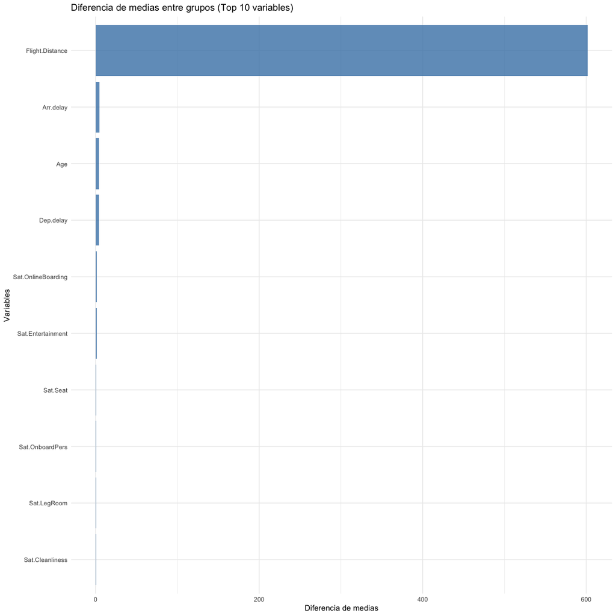

```r
# Gráfico de barras
plot_data <- data.frame(
  Variable = names(top_10),
  Diferencia = as.numeric(top_10)
)

p <- ggplot(plot_data, aes(x = reorder(Variable, Diferencia), y = Diferencia)) +
  geom_col(fill = "steelblue", alpha = 0.8) +
  coord_flip() +
  labs(title = "Diferencia de medias entre grupos (Top 10 variables)",
       x = "Variables", y = "Diferencia de medias") +
  theme_minimal()

print(p)
```

```r
# 5. COEFICIENTES DE LA FUNCIÓN DISCRIMINANTE
cat("\n### 4. COEFICIENTES DE LA FUNCIÓN DISCRIMINANTE\n\n")
```

```
### 4. COEFICIENTES DE LA FUNCIÓN DISCRIMINANTE
```

```r
# Extraer coeficientes
coeficientes <- as.data.frame(modelo_lda$scaling)
coeficientes$Variable <- rownames(coeficientes)
coeficientes <- coeficientes |> dplyr::select(Variable, LD1)

# Top 15 por importancia
coef_ordenados <- coeficientes |>
  arrange(desc(abs(LD1))) |>
  slice(1:15)

cat("#### Top 15 variables por importancia en función discriminante:\n")
```

```
#### Top 15 variables por importancia en función discriminante:
```

```r
print(kable(coef_ordenados,
           caption = "Top 15 coeficientes de la función discriminante",
           align = c("l", "c")) |>
  kable_styling(bootstrap_options = c("striped", "hover"),
                full_width = FALSE) |>
  column_spec(1, bold = TRUE))
```

Top 15 coeficientes de la función discriminante

|  | Variable | LD1 |
| --- | --- | --- |
| Type.TravelPersonal Travel | Type.TravelPersonal Travel | -1.5448871 |
| Customer.TypeLoyal Customer | Customer.TypeLoyal Customer | 1.2508005 |
| ClassEco Plus | ClassEco Plus | -0.5811499 |
| ClassEco | ClassEco | -0.5203702 |
| Sat.OnlineBoarding | Sat.OnlineBoarding | 0.3227462 |
| Sat.wifi | Sat.wifi | 0.2731016 |
| Sat.onlineBooking | Sat.onlineBooking | -0.1642655 |
| Sat.CheckIn | Sat.CheckIn | 0.1495869 |
| Sat.OnboardPers | Sat.OnboardPers | 0.1408669 |
| Sat.LegRoom | Sat.LegRoom | 0.1339893 |
| Sat.Cleanliness | Sat.Cleanliness | 0.1017757 |
| Sat.Baggage | Sat.Baggage | 0.0667443 |
| Sat.Entertainment | Sat.Entertainment | 0.0666327 |
| Sat.DepArr | Sat.DepArr | -0.0653174 |
| Sat.InflightServ | Sat.InflightServ | 0.0579571 |

```r
# 6. DEPURACIÓN DEL MODELO
cat("\n### 5. DEPURACIÓN DEL MODELO: Variables con baja discriminación\n\n")
```

```
### 5. DEPURACIÓN DEL MODELO: Variables con baja discriminación
```

```r
# Variables con diferencia < 0.1
vars_baja_discriminacion <- names(diferencias[abs(diferencias) < 0.1])

if (length(vars_baja_discriminacion) > 0) {
  cat("#### Variables con baja discriminación (diferencia < 0.1):\n")
  cat(paste(vars_baja_discriminacion, collapse = ", "), "\n\n")

  cat("Estas variables presentan medias muy similares entre grupos y por lo tanto\n")
  cat("tienen bajo poder discriminante. Se recomienda considerar su eliminación\n")
  cat("para mejorar la interpretabilidad del modelo.\n\n")
} else {
  cat("#### Todas las variables muestran poder discriminante significativo\n\n")
}
```

```
#### Variables con baja discriminación (diferencia < 0.1):
GenderMale, ClassEco Plus, Sat.Gate

Estas variables presentan medias muy similares entre grupos y por lo tanto
tienen bajo poder discriminante. Se recomienda considerar su eliminación
para mejorar la interpretabilidad del modelo.
```

```r
# 7. GRÁFICO DE DISTRIBUCIÓN DE PUNTUACIONES DISCRIMINANTES
cat("\n### 6. DISTRIBUCIÓN DE PUNTUACIONES DISCRIMINANTES\n\n")
```

```
### 6. DISTRIBUCIÓN DE PUNTUACIONES DISCRIMINANTES
```

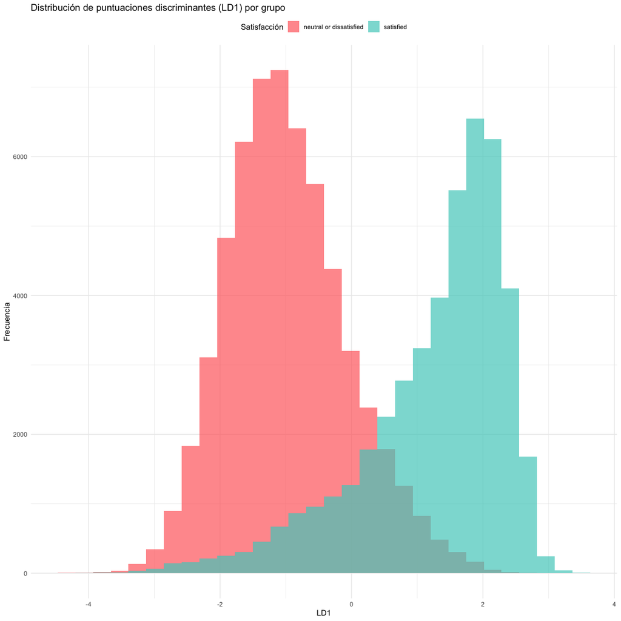

```r
# Extraer puntuaciones discriminantes
scores_lda <- pred_lda$x

# Gráfico de distribución por grupo
plot_data_dist <- data.frame(
  LD1 = scores_lda[, 1],
  Group = as.factor(train_lda$Satisfaction)
)

p_dist <- ggplot(plot_data_dist, aes(x = LD1, fill = Group)) +
  geom_histogram(bins = 30, alpha = 0.7, position = "identity") +
  scale_fill_manual(values = c("#FF6B6B", "#4ECDC4")) +
  labs(title = "Distribución de puntuaciones discriminantes (LD1) por grupo",
       x = "LD1", y = "Frecuencia",
       fill = "Satisfacción") +
  theme_minimal() +
  theme(legend.position = "top")

print(p_dist)
```

```r
cat("Este gráfico muestra cómo se separan los dos grupos (satisfied y neutral or dissatisfied)\n")
```

```
Este gráfico muestra cómo se separan los dos grupos (satisfied y neutral or dissatisfied)
```

```r
cat("según las puntuaciones del primer discriminante lineal (LD1).\n\n")
```

```
según las puntuaciones del primer discriminante lineal (LD1).
```

```r
# 8. CURVA ROC
cat("\n### 7. CURVA ROC\n\n")
```

```
### 7. CURVA ROC
```

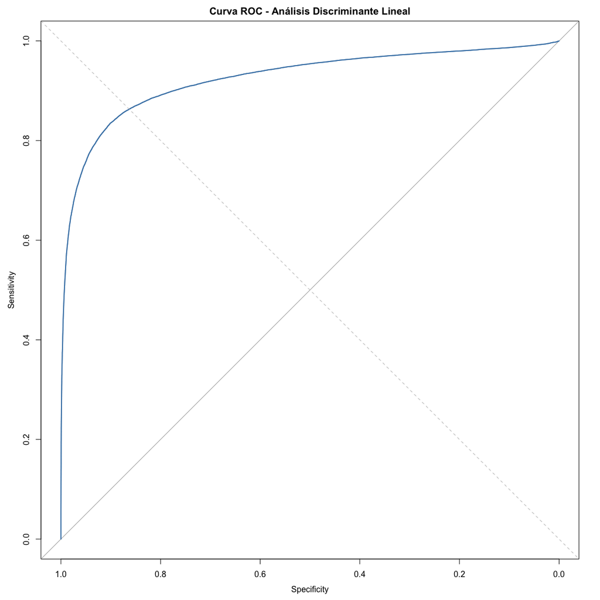

```r
# Probabilidades posteriores
probs_lda <- pred_lda$posterior[, 2]

# Crear curva ROC
roc_lda <- roc(train_lda$Satisfaction, probs_lda)

# Plotear
plot(roc_lda,
     main = "Curva ROC - Análisis Discriminante Lineal",
     col = "steelblue", lwd = 2)
abline(a = 0, b = 1, lty = 2, col = "gray")
```